# Data608-Week07-Discussion

Pavan Akula

March 13, 2018

Using *Dow Jones Industrials Index* and *Gold Price* from 2002 to 2017, I will be investigating if there is a relationship between market direction and gold prices. Website https://www.sunshineprofits.com/gold-silver/dictionary/dow-jones-gold/ says stock prices and gold prices are inversely related, meaning when stock prices move upwards, gold prices move downward and vice versa.

*Gold Price* data is obtained from https://fred.stlouisfed.org/series/GOLDAMGBD228NLBM and *Dow Jones Industrials Index* data is downloaded from https://finance.yahoo.com/quote/%5EDJI/history?period1=1009861200&period2=1514696400&interval=1d&filter=history&frequency=1d.

I will be using following graphs

- Double Y-axis Line Chart
- Year over year Correlation Bar Chart
- The Phillips Curve Chart

According to *wikipedia*, *The Phillips Curve* is best way find out inverse correlation.

```r
library(knitr)
library(kableExtra)
library(ggplot2)
library(ggrepel)
library(tidyverse)
library(scales)

#Load data
gold.df <- read.csv("D:\\CUNY\\608\\Week07\\GOLDAMGBD228NLBM_15.csv", header= TRUE, stringsAsFactors = F)
colnames(gold.df) <- c("Date","Gold")

gold.df <- gold.df %>%
  separate(col = Date, into = c("Year", "Month", "Day"), sep = "\\-") %>%
  select(Year, Month, Day, Gold) %>%
  mutate(Year = as.integer(Year),
         Month = as.integer(Month),
         Day = as.integer(Day),
         Gold = as.numeric(Gold)
         )

df <- gold.df[complete.cases(gold.df),] %>%
  group_by(Year, Month) %>%
  filter(Day == max(Day)) %>%
  select(Year, Month, Gold) %>%
  # mutate(Month_Year = paste(as.character(Year), '-', as.character(Month))) %>%
  # select(Month_Year,Gold)
  group_by(Year) %>%
  filter(Month == max(Month)) %>%
  select(Year, Gold)

dow.df <- read.csv("D:\\CUNY\\608\\Week07\\DOW_15.csv", header= TRUE, stringsAsFactors = F)

dow.df <- dow.df %>%
  separate(col = Date, into = c("Year", "Month", "Day"), sep = "\\-") %>%
  select(Year, Month, Day, Adj.Close) %>%
  mutate(Year = as.integer(Year),
         Month = as.integer(Month),
         Day = as.integer(Day),
         Dow = as.numeric(Adj.Close)
         )

df <- dow.df[complete.cases(dow.df),] %>%
  group_by(Year, Month) %>%
  filter(Day == max(Day)) %>%
  select(Year, Month, Dow) %>%
  # mutate(Month_Year = paste(as.character(Year), '-', as.character(Month))) %>%
  # select(Month_Year,Dow) %>%
  # inner_join(df, by = "Month_Year")
  group_by(Year) %>%
  filter(Month == max(Month)) %>%
  select(Year, Dow) %>%
  inner_join(df, by = "Year")

df <- data.frame(df)

df %>%
  kable(format="html", caption = "Gold Price Vs. Dow Jones Industrials Index, 2002 - 2017") %>%
  kable_styling(bootstrap_options = c("striped", "hover", "condensed", "responsive"), position = "left")
```

Gold Price Vs. Dow Jones Industrials Index, 2002 - 2017

| Year | Dow | Gold |
| --- | --- | --- |
| 2002 | 8341.63 | 342.75 |
| 2003 | 10453.92 | 417.25 |
| 2004 | 10783.01 | 438.00 |
| 2005 | 10717.50 | 513.00 |
| 2006 | 12463.15 | 635.70 |
| 2007 | 13264.82 | 836.50 |
| 2008 | 8776.39 | 865.00 |
| 2009 | 10428.05 | 1104.00 |
| 2010 | 11577.51 | 1410.25 |
| 2011 | 12217.56 | 1574.50 |
| 2012 | 13104.14 | 1664.00 |
| 2013 | 16576.66 | 1201.50 |
| 2014 | 17823.07 | 1199.25 |
| 2015 | 17425.03 | 1062.25 |
| 2016 | 19762.60 | 1159.10 |
| 2017 | 24719.22 | 1296.50 |

From the table we can clearly see in last 15 years, when stock market dropped in 2008, gold price went up.

#### Double Y-axis Line Chart

The blue line indicates *Dow Jones Industrials Index* movement and the red line suggests `Gold Price`. Left Y-axis show `Dow Jones` scale and right side Y-axis show `Gold Price`. We can see until the year 2007 both `Dow Jones` and `Gold Price` were moving upward. In 2007 stock market dropped, indicating a drop in `Dow Jones Index` while gold price moved up. In the latter part of the year, 2012 gold price dropped while stock market moved up.

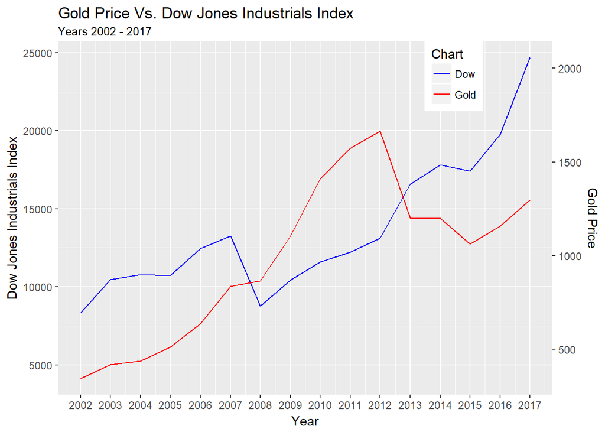

```r
ggplot(df, aes(x = as.integer(Year))) +
  geom_line(aes(y = Dow, colour = "Dow")) +
  geom_line(aes(y = Gold*12, colour = "Gold")) +
  scale_y_continuous(sec.axis = sec_axis(~./12,name = "Gold Price")) +
  scale_x_continuous(breaks=seq(2001,2018,1)) +
  scale_colour_manual(values = c("blue", "red")) +
  labs(y = "Dow Jones Industrials Index", x = "Year", colour = "Chart", title = "Gold Price Vs. Dow Jones Industrials Index", subtitle = "Years 2002 - 2017") +
  theme(legend.position = c(0.8, 0.9))
```

#### Year over year Correlation Bar Chart

The chart suggests that in last 15 years from 2002 to 2017, `Dow Jones Index` and `Gold Price` were in an inverse relationship four times.

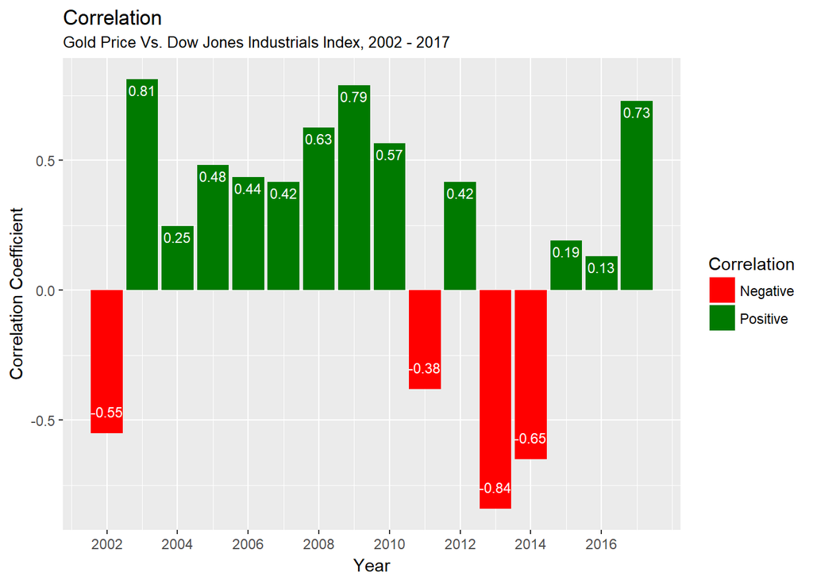

```r
cor.df <- gold.df[complete.cases(gold.df),] %>%
  inner_join(dow.df[complete.cases(dow.df),], by=c("Year","Month","Day")) %>%
  select(Year,Month, Day, Gold, Dow) %>%
  group_by(Year, Month) %>%
  filter(Day == max(Day)) %>%
  select(Year, Month, Gold, Dow) %>%
  group_by(Year) %>%
  mutate(cor = cor(Gold,Dow)) %>%
  select (Year, cor)

cor.df <- data.frame(cor.df)
cor.df <- cor.df %>%
  distinct() %>%
  mutate(Correlation = ifelse(cor > 0,'Positive','Negative'),
         offset = ifelse(cor > 0, 1.5,-1.5))

ggplot(cor.df, aes(x=Year, y=cor, fill=Correlation)) +
  geom_bar(stat='identity', position = 'identity') +
  scale_fill_manual(values=c('red','#007a00'))+
  geom_text(aes(label=round(cor,2)), vjust = cor.df$offset, color='white', size=3)+
  scale_x_continuous(breaks=seq(2002,2017,2))+
  labs(title = sprintf("Correlation"), subtitle = "Gold Price Vs. Dow Jones Industrials Index, 2002 - 2017") + xlab("Year") + ylab("Correlation Coefficient")
```

#### The Phillips Curve Chart

Using, The Phillips Curve we draw some inference when stock market drops do gold price go up. `Gold Price` is mapped as X-axis and `Dow Jones Industrials Index` is on Y-axis. The third dimension `Year` is mapped along the line indicating the rate of change.

During years 2007 and 2008 stock market dropped, we notice a change in Y-axis and X-axis. Drop in Y-axis and increase in X-axis. From the year 2008 to 2012 rate of change in X-axis is higher than Y-axis, which means `Gold Price` increased more rapidly than `Dow Jones Industrials Index`. It tells investors were investing more in gold compared to stock market. From 2012 to 2013, `Dow Jones` moved higher more rapidly and `Gold Price` dropped, suggesting investors were making a shift in their investment strategy. Selling gold and moving into stocks. From 2013 to 2017 Y-axis increased rapidly than X-axis, indicating stock market moved higher quickly compared to gold price. It suggests investors are heavily investing in stocks compared to gold.

Purpose of the Phillips Curve was to identify the relationship between unemployment and inflation, but I think it is useful for other purposes also.

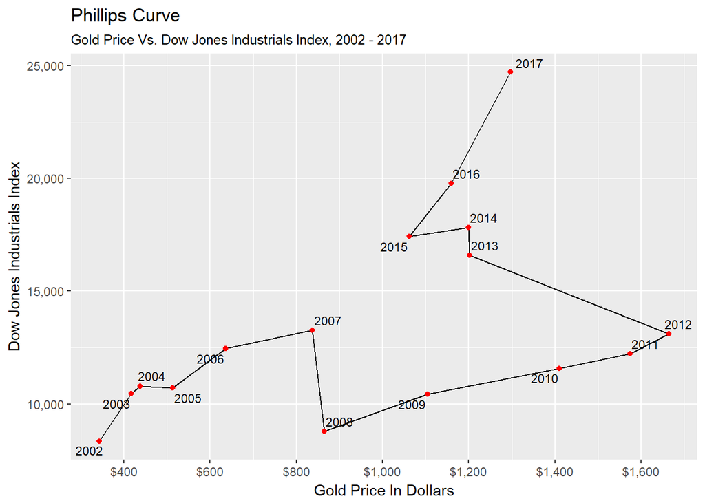

```r
ggplot(df, aes(x=Gold,y=Dow)) +
  geom_path() +
  geom_point(color="red") +
  geom_text_repel(data=df, aes(label=Year), size=3) +
  scale_x_continuous(label=dollar_format(), breaks=seq(400,1600,200)) +
  scale_y_continuous(label=comma) +
  labs(title = sprintf("Phillips Curve"), subtitle = "Gold Price Vs. Dow Jones Industrials Index, 2002 - 2017") + xlab("Gold Price In Dollars") + ylab("Dow Jones Industrials Index")
```

#### References

- https://en.wikipedia.org/wiki/Phillips_curve
- https://rpubs.com/escott8908/RGC_Ch3_Gar_Graphs
- https://rstudio-pubs-static.s3.amazonaws.com/228019_f0c39e05758a4a51b435b19dbd321c23.html
- https://courses.lumenlearning.com/boundless-economics/chapter/the-relationship-between-inflation-and-unemployment/
- https://www.economist.com/blogs/graphicdetail/2017/11/daily-chart
- https://stackoverflow.com/questions/8136770/conditional-text-formatting-with-ggplot
- https://rpubs.com/MarkusLoew/226759